# Introduction to R

Version: 08 März 2023

## Plan for today

1. R and RStudio: What? Why?
2. Workshop organization
3. R’s object-oriented logic
4. The basic objects

## R and RStudio

## A language for statistical computing and graphics

- **High-level** programming language with pre-defined data structures, functions, control structures, …
- Developed by the **R Core Team** (since 1997), hosted on **CRAN** (Comprehensive R Archive Network)
- **Free** and available for **Windows, Mac, and Linux**
- Download from [CRAN](https://cran.r-project.org/)

[figure not shown]

## Packages

[figure not shown]

## Packages

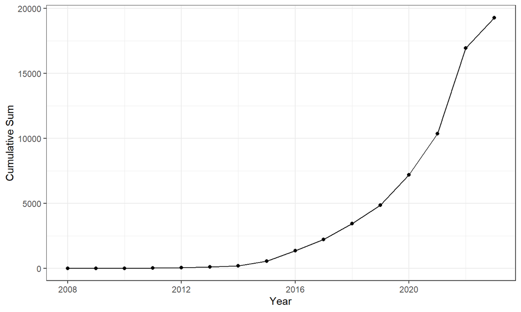

Number of packages on CRAN by year

## Horrible graphical user interface

[figure not shown]

## RStudio: Integrated development environment

- Provides **convenient features** for R
  - Syntax highlighting
  - Code auto-completion
  - Workplace management
  - File management
  - …
- **Free** and available for **Windows, Mac, and Linux**
- Download from [posit](https://posit.co/downloads/)

[figure not shown]

## RStudio: Integrated development environment

[figure not shown]

## Course organization

## Course organization

**Part I: Base R**

- Session 1: Vectors, matrices, data frames, and lists
- Session 2: Basic programming (functions and control structures)

**Part II: Tidyverse and data analysis**

- Session 3: Importing data, Tidyverse for data preparation
- Homework: Preparing the ALLBUS 2021
- Session 4: Data visualization, descriptive statistics, regression models

## The pains and joys of learning a new language

**Learning a new programming language** is a bit like learning…

[figure not shown]

## The pains and joys of learning a new language

**Most importantly:** Learning a programming language means learning how to…

[figure not shown]

## Object-oriented logic

## Object-oriented logic

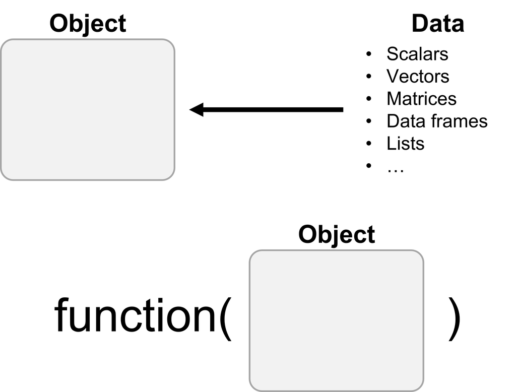

## Basic objects

## What will we learn?

- How to **create** an object (scalar, vector, …)?
- **Naming** rules
- Which **types of data** can be stored in objects?
- **Attributes** of objects
- How to **subset** an object?
- What can we do with an object (unitary and logical **operators**)?

## How to create an object?

- Objects are created with the **assignment operator** “<-” (Shortcut: alt -)

```r
my.vec <- c(1, 2)
my.vec
```

```
## [1] 1 2
```

- Naming rules: Names are not allowed to…
  - **begin** with a **number** (not: 1st.vec)
  - contain **white spaces** (not: my vec)
  - contain **reserved words** (e.g., “$” or “+”)
- Names are **case sensitive**: myVec != myvec

## Which types of data can be stored in objects?

- Three basic types: numeric, character, logical

```r
num.vec <- c(1, 2, 3)
char.vec <- c("a", "b", "c")
logic.vec <- c(TRUE, FALSE, TRUE)
```

## Which types of data can be stored in objects?

**Test the type of a vector**

```r
class(num.vec)
```

```
## [1] "numeric"
```

```r
is.numeric(num.vec)
```

```
## [1] TRUE
```

## Which types of data can be stored in objects?

**Test the type of a vector**

```r
is.character(num.vec)
```

```
## [1] FALSE
```

```r
is.logical(num.vec)
```

```
## [1] FALSE
```

- Let’s switch to R!